# Practical Machine Learning Course Project

# 1 Overview

This report is prepared as part of the course project for the practical machine learning course, which is prepared using knitr functions in RStudio. The goal of this project is to predict the performance of participants exercise through prediction of the variable ‘classe’ in the training dataset. Several machine learning methods are compared and the best method is used to predict the test dataset.

# 2 Background

Using devices such as Jawbone Up, Nike FuelBand, and Fitbit it is now possible to collect a large amount of data about personal activity relatively inexpensively. These type of devices are part of the quantified self movement - a group of enthusiasts who take measurements about themselves regularly to improve their health, to find patterns in their behavior, or because they are tech geeks. One thing that people regularly do is quantify how much of a particular activity they do, but they rarely quantify how well they do it. In this project, your goal will be to use data from accelerometers on the belt, forearm, arm, and dumbell of 6 participants. They were asked to perform barbell lifts correctly and incorrectly in 5 different ways. More information is available from the website here: http://groupware.les.inf.puc-rio.br/har (see the section on the Weight Lifting Exercise Dataset).

Read more: http://groupware.les.inf.puc-rio.br/har#ixzz3xsbS5bVX

# 3 Data and Exploratory Analysis

## 3.1 Dataset

The training data for this project are available here:

https://d396qusza40orc.cloudfront.net/predmachlearn/pml-training.csv

The test data are available here:

https://d396qusza40orc.cloudfront.net/predmachlearn/pml-testing.csv

The data for this project come from http://groupware.les.inf.puc-rio.br/har.

Full source: (Thanks to authors for providing the data) Velloso, E.; Bulling, A.; Gellersen, H.; Ugulino, W.; Fuks, H. “Qualitative Activity Recognition of Weight Lifting Exercises. Proceedings of 4th International Conference in Cooperation with SIGCHI (Augmented Human ’13)”. Stuttgart, Germany: ACM SIGCHI, 2013.

## 3.2 R Packages

We first setup the R packages that are necessary for the complete analysis.

## 3.3 Data Load and Cleaning

The training and test datasets are downloaded using the provided URLs. The training dataset divided into two parts: 70% of the data belongs to training set, while 30% of the data belongs to the test set. The testing dataset remains unchanged.

```r
# download the datasets
train <- read.csv('train.csv')
test  <- read.csv('test.csv')
```

```r
# create a partition with the training dataset
trainPart  <- createDataPartition(train$classe, p=0.7, list=FALSE)
trainTrainSet <- train[trainPart, ]
trainTestSet  <- train[-trainPart, ]
dim(trainTrainSet)
```

```
## [1] 13737   160
```

```r
dim(trainTestSet)
```

```
## [1] 5885  160
```

Train dataset has 160 variables. There are variables with pleanty of ‘NAs’ and near zero variance, which have been removed below.

```r
# remove variables with near zero variance
nearZeroVariance <- nearZeroVar(trainTrainSet)
trainTrainSet <- trainTrainSet[, -nearZeroVariance]
trainTestSet  <- trainTestSet[, -nearZeroVariance]
dim(trainTrainSet)
```

```
## [1] 13737   107
```

```r
dim(trainTestSet)
```

```
## [1] 5885  107
```

```r
# remove variables with >95% NAs
varNAs    <- sapply(trainTrainSet, function(x) mean(is.na(x))) > 0.95
trainTrainSet <- trainTrainSet[, varNAs==FALSE]
trainTestSet  <- trainTestSet[, varNAs==FALSE]
dim(trainTrainSet)
```

```
## [1] 13737    59
```

```r
dim(trainTestSet)
```

```
## [1] 5885   59
```

```r
# removing the identification only variables (columns 1 to 5)
trainTrainSet <- trainTrainSet[, -(1:5)]
trainTestSet  <- trainTestSet[, -(1:5)]
dim(trainTrainSet)
```

```
## [1] 13737    54
```

```r
dim(trainTestSet)
```

```
## [1] 5885   54
```

We have 54 variables after removing variables with more than 95% NAs, near zero variance and identification only variables.

## 3.4 Correlation analysis

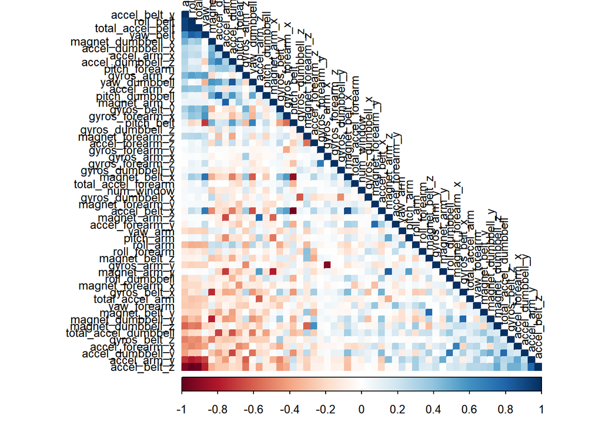

```r
corMatrix <- cor(trainTrainSet[, -54])
corrplot(corMatrix, order = "FPC", method = "color", type = "lower",
         tl.cex = 0.8, tl.col = rgb(0, 0, 0))
```

The dark colors indicate the variables are highly correlated in the figure given above.

# 4 Prediction Model Building

Three methods are used on train dataset and the method with highest accuracy is used to predict test dataset (30% of the traning dataset) and the project test dataset for quiz prediction. These methods are random forest, decision tree and generalized boosted model.

## 4.1 Random Forest Method

```r
# fit random forest
set.seed(36478)
trainControlRF <- trainControl(method="cv", number=3, verboseIter=FALSE)
fitRandForest <- train(classe ~ ., data=trainTrainSet, method="rf",
                          trControl=trainControlRF)
fitRandForest$finalModel
```

```
##
## Call:
##  randomForest(x = x, y = y, mtry = param$mtry)
##                Type of random forest: classification
##                      Number of trees: 500
## No. of variables tried at each split: 27
##
##         OOB estimate of  error rate: 0.2%
## Confusion matrix:
##      A    B    C    D    E class.error
## A 3906    0    0    0    0 0.000000000
## B    4 2650    4    0    0 0.003009782
## C    0    5 2391    0    0 0.002086811
## D    0    0   10 2242    0 0.004440497
## E    0    0    0    4 2521 0.001584158
```

```r
# prediction on Training Test dataset
set.seed(36478)
predictRF <- predict(fitRandForest, newdata=trainTestSet)
#str(predictRF)
#str(trainTestSet$classe)
confMatRF <- confusionMatrix(predictRF, as.factor(trainTestSet$classe))
confMatRF
```

```
## Confusion Matrix and Statistics
##
##           Reference
## Prediction    A    B    C    D    E
##          A 1672    1    0    0    0
##          B    1 1137    3    0    0
##          C    0    1 1023    6    0
##          D    0    0    0  957    0
##          E    1    0    0    1 1082
##
## Overall Statistics
##
##                Accuracy : 0.9976
##                  95% CI : (0.996, 0.9987)
##     No Information Rate : 0.2845
##     P-Value [Acc > NIR] : < 2.2e-16
##
##                   Kappa : 0.997
##
##  Mcnemar's Test P-Value : NA
##
## Statistics by Class:
##
##                      Class: A Class: B Class: C Class: D Class: E
## Sensitivity            0.9988   0.9982   0.9971   0.9927   1.0000
## Specificity            0.9998   0.9992   0.9986   1.0000   0.9996
## Pos Pred Value         0.9994   0.9965   0.9932   1.0000   0.9982
## Neg Pred Value         0.9995   0.9996   0.9994   0.9986   1.0000
## Prevalence             0.2845   0.1935   0.1743   0.1638   0.1839
## Detection Rate         0.2841   0.1932   0.1738   0.1626   0.1839
## Detection Prevalence   0.2843   0.1939   0.1750   0.1626   0.1842
## Balanced Accuracy      0.9993   0.9987   0.9978   0.9964   0.9998
```

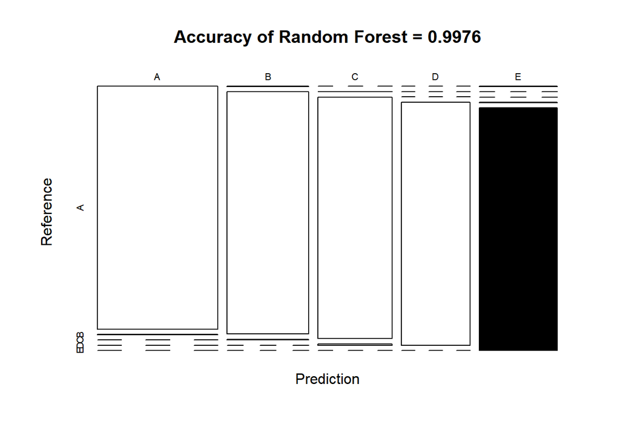

```r
# plot matrix results
set.seed(36478)
plot(confMatRF$table, col = confMatRF$byClass,
     main = paste("Accuracy of Random Forest =",
                  round(confMatRF$overall['Accuracy'], 4)))
```

# 4.2 Decision Trees Method

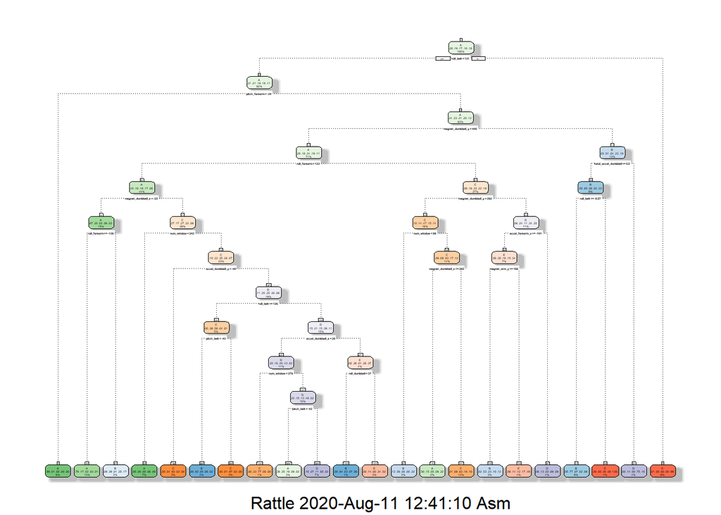

```r
# fit decision trees
set.seed(36478)
fitDecisionTrees <- rpart(classe ~ ., data=trainTrainSet, method="class")
fancyRpartPlot(fitDecisionTrees)
```

```r
# prediction on training test dataset
set.seed(36478)
predictDecisionTrees <- predict(fitDecisionTrees, newdata=trainTestSet, type="class")
confMatDecisionTrees <- confusionMatrix(predictDecisionTrees, as.factor(trainTestSet$classe))
confMatDecisionTrees
```

```
## Confusion Matrix and Statistics
##
##           Reference
## Prediction    A    B    C    D    E
##          A 1501  187   43   77   84
##          B   54  715   82   94  134
##          C    5   81  821  137   57
##          D   94   97   57  555   50
##          E   20   59   23  101  757
##
## Overall Statistics
##
##                Accuracy : 0.739
##                  95% CI : (0.7276, 0.7502)
##     No Information Rate : 0.2845
##     P-Value [Acc > NIR] : < 2.2e-16
##
##                   Kappa : 0.6682
##
##  Mcnemar's Test P-Value : < 2.2e-16
##
## Statistics by Class:
##
##                      Class: A Class: B Class: C Class: D Class: E
## Sensitivity            0.8967   0.6277   0.8002  0.57573   0.6996
## Specificity            0.9071   0.9233   0.9424  0.93944   0.9577
## Pos Pred Value         0.7933   0.6627   0.7457  0.65064   0.7885
## Neg Pred Value         0.9567   0.9118   0.9571  0.91872   0.9340
## Prevalence             0.2845   0.1935   0.1743  0.16381   0.1839
## Detection Rate         0.2551   0.1215   0.1395  0.09431   0.1286
## Detection Prevalence   0.3215   0.1833   0.1871  0.14494   0.1631
## Balanced Accuracy      0.9019   0.7755   0.8713  0.75758   0.8287
```

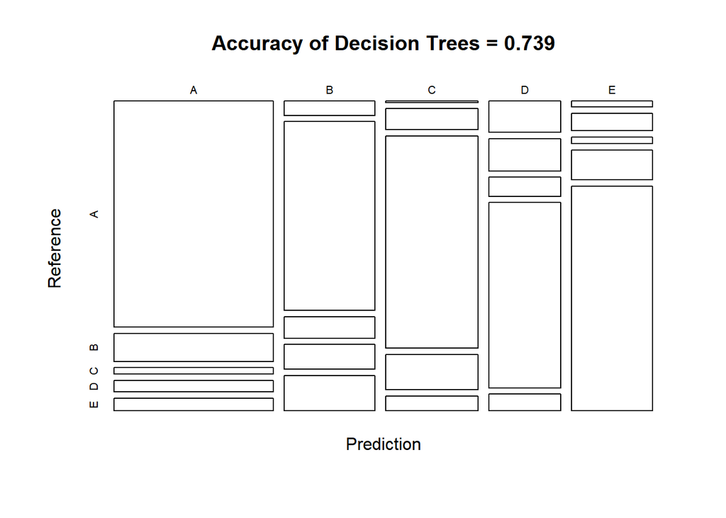

```r
# plot matrix results
set.seed(36478)
plot(confMatDecisionTrees$table, col = confMatDecisionTrees$byClass,
     main = paste("Accuracy of Decision Trees =",
                  round(confMatDecisionTrees$overall['Accuracy'], 4)))
```

# 4.3 Generalized Boosted Method

```r
# generalized boosted model fit
set.seed(36478)
conGBM <- trainControl(method = "repeatedcv", number = 4, repeats = 1)
fitGBM  <- train(classe ~ ., data=trainTrainSet, method = "gbm",
                    trControl = conGBM, verbose = FALSE)
fitGBM$finalModel
```

```
## A gradient boosted model with multinomial loss function.
## 150 iterations were performed.
## There were 53 predictors of which 53 had non-zero influence.
```

```r
# prediction of training test dataset
set.seed(36478)
predGBM <- predict(fitGBM, newdata=trainTestSet)
confMatGBM <- confusionMatrix(predGBM, as.factor(trainTestSet$classe))
confMatGBM
```

```
## Confusion Matrix and Statistics
##
##           Reference
## Prediction    A    B    C    D    E
##          A 1671   11    0    0    0
##          B    2 1108   11    2    5
##          C    0   19 1012   11    2
##          D    1    1    3  951    3
##          E    0    0    0    0 1072
##
## Overall Statistics
##
##                Accuracy : 0.9879
##                  95% CI : (0.9848, 0.9906)
##     No Information Rate : 0.2845
##     P-Value [Acc > NIR] : < 2.2e-16
##
##                   Kappa : 0.9847
##
##  Mcnemar's Test P-Value : NA
##
## Statistics by Class:
##
##                      Class: A Class: B Class: C Class: D Class: E
## Sensitivity            0.9982   0.9728   0.9864   0.9865   0.9908
## Specificity            0.9974   0.9958   0.9934   0.9984   1.0000
## Pos Pred Value         0.9935   0.9823   0.9693   0.9917   1.0000
## Neg Pred Value         0.9993   0.9935   0.9971   0.9974   0.9979
## Prevalence             0.2845   0.1935   0.1743   0.1638   0.1839
## Detection Rate         0.2839   0.1883   0.1720   0.1616   0.1822
## Detection Prevalence   0.2858   0.1917   0.1774   0.1630   0.1822
## Balanced Accuracy      0.9978   0.9843   0.9899   0.9924   0.9954
```

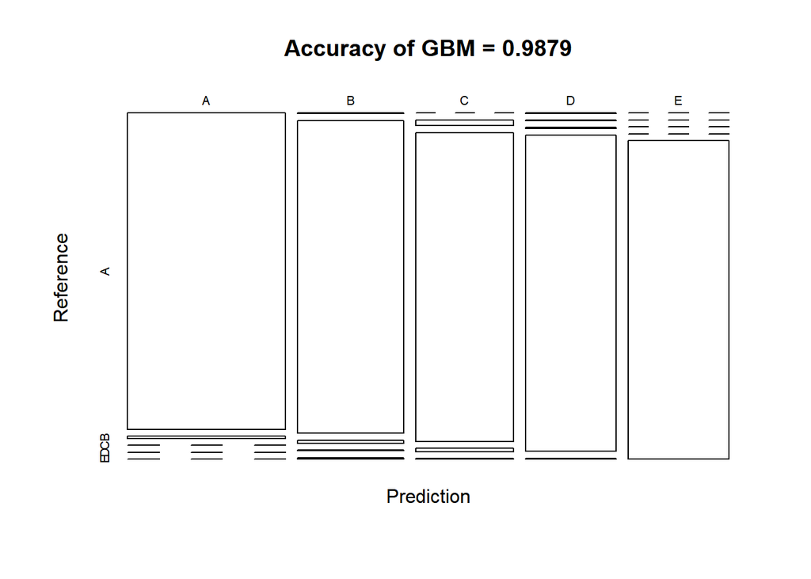

```r
# plot matrix results
set.seed(36478)
plot(confMatGBM$table, col = confMatGBM$byClass,
     main = paste("Accuracy of GBM =", round(confMatGBM$overall['Accuracy'], 4)))
```

# 5 Selection of the best method and prediction of test dataset

The random forest method is selected to predict the 20 test quiz dataset as it has the highest accuracy compared to decision trees and generalized boosted methods. The results of the prediction are given below.

```r
# plot matrix results
predictTEST <- predict(fitRandForest, newdata=test)
predictTEST
```

```
##  [1] B A B A A E D B A A B C B A E E A B B B
## Levels: A B C D E
```